# BIOL 607 Homework 3

Nina McDonnell

10/2/2020

## 1. Sample Properties

### Consider the following vasopressin levels in voles.

```r
vole_vaso <- c(98,96,94,88,86,82,77,74,70,60,
               59,52,50,47,40,35,29,13,6,5)
```

### 1a. Say “Vole vasopressin” 10 times as fast as you can. How many times did you trip up?

Actually, not at all! I am genuinely surprised because usually I don’t do well with tongue-twisters!

### 1b. What is the mean, median, sd, and interquartile range of the sample?

```r
#use functions to calculate mean, median, SD, and IQR of the vector:
mean(vole_vaso)
```

```
## [1] 58.05
```

```r
median(vole_vaso)
```

```
## [1] 59.5
```

```r
sd(vole_vaso)
```

```
## [1] 29.75244
```

```r
IQR(vole_vaso)
```

```
## [1] 44.25
```

The mean of the sample is 58.05, the median is 59.5, the SD is 29.7524435, and the IQR is 44.25.

### 1c. What is the standard error of the mean (do this with a formula!)?

```r
#Make a function to calculate SE more easily:
se_mean <- function(x){
  ret_value <- (sd(x))/(sqrt(length(x))) #function will calculate SE of mean based on formula: SD(X)/sqrt(n)
  return(ret_value)
}

se_mean(vole_vaso) #use function to get SE of vole vasopressin sample. SE= 6.65
```

```
## [1] 6.652849
```

The SE of the mean of the vole vasopressin sample is 6.6528486.

### 1d. What does the standard error of the mean tell you about our estimate of the mean values of the population of vole vassopressin?

The SE of the mean tells us how accurately our sample mean reflects the population mean. For vole vasopressin, most sample means will be within 6.65 units of the population mean.

## 2. Sample Size for upper quartiles.

### We can get the upper quartile value of vole vassopressin with

```r
quantile(vole_vaso, probs = 0.75)
```

```
## 75%
##  83
```

### Let’s assume the sample is representative of the population.

### 2a. Use sample() to get just one resample with a sample size of 10. What is its upper quartile?

```r
vole_vaso_sim <- sample(vole_vaso, #resample 10 from vole_vaso with replacement
                        size=10,
                        replace = TRUE) %>%
  quantile(probs=0.75) #calculate upper quartile of resample values

vole_vaso_sim
```

```
##   75%
## 59.75
```

The upper quantile of the resampled values is 59.75.

### 2b. Build an initial data frame for simulations with the sample sizes 5 through 20.

```r
set.seed(802) #make simulations replicable. Used old area code, 802

boot_vole_vaso <- data.frame(samp_size=5:20) #data frame with sample sizes 5-20

boot_vole_vaso
```

```
##    samp_size
## 1          5
## 2          6
## 3          7
## 4          8
## 5          9
## 6         10
## 7         11
## 8         12
## 9         13
## 10        14
## 11        15
## 12        16
## 13        17
## 14        18
## 15        19
## 16        20
```

### 2c. Use this data frame to get simulated upper quartiles at each sample size 1,000 times (i.e., for 1,000 simulations).

```r
boot_vole_vaso2 <- boot_vole_vaso %>%
  rowwise(samp_size) %>% #calculate across rows/ for each sample
  #simulate vole_vaso data for sample sizes 5-20, 1000 times
  summarize(boot_quantile=replicate(1000,
                                    quantile(sample(vole_vaso,
                                           size=samp_size,
                                           replace= TRUE), probs=0.75))) #calculate quantile of values from vole_vaso simulation

boot_vole_vaso2
```

```
## # A tibble: 16,000 x 2
## # Groups:   samp_size [16]
##    samp_size boot_quantile
##        <int>         <dbl>
##  1         5            88
##  2         5            96
##  3         5            77
##  4         5            59
##  5         5            40
##  6         5            74
##  7         5            74
##  8         5            74
##  9         5            98
## 10         5            40
## # … with 15,990 more rows
```

### 2d. With a ggplot, make a guesstimate as to the best sample size for estimating the upper quartile of the population. Use whatever geom you feel makes things most easy to see. E.C. Add a red dashed line using geom_vline() or geom_hline() to show where that should be, perhaps.

The range of upper quartile values looks similar after a sample size of 14-15, so this is probably sufficient for estimating the population parameter.

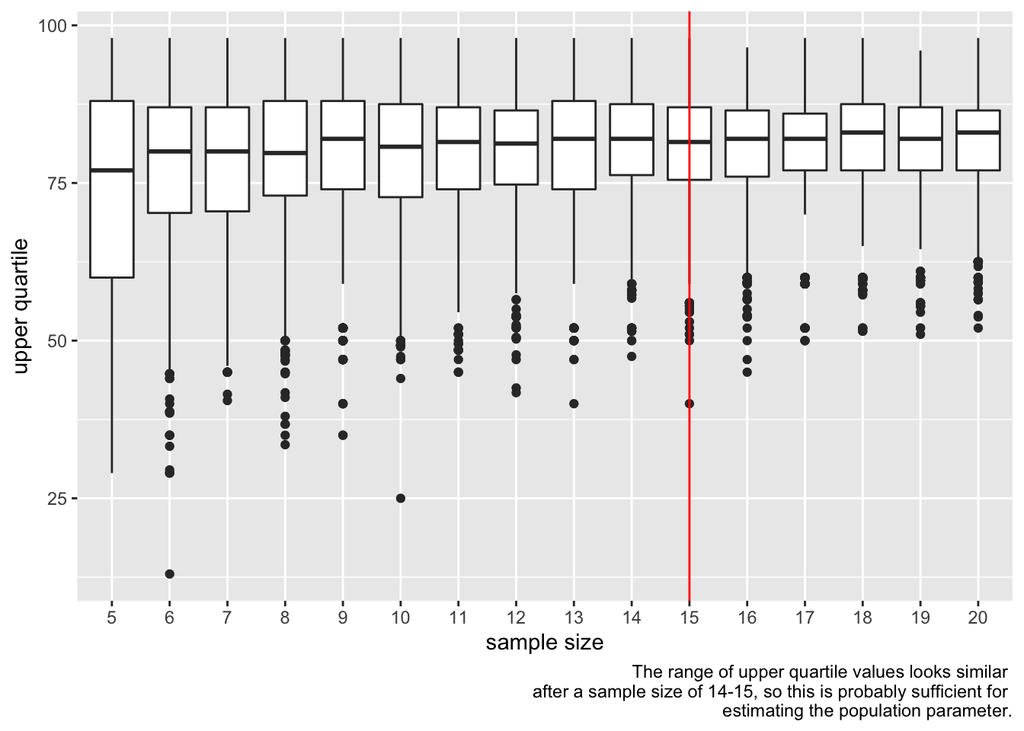

```r
guesstimate <- boot_vole_vaso2 %>%
  mutate(samp_size_factor=as.factor(samp_size)) %>% #mutate sample size to factor so that boxplots can be made to show variability in quantile values estimated at each sample size.
  ggplot(mapping= aes(x=samp_size_factor, y= boot_quantile))+
  geom_boxplot()+
  geom_vline(xintercept = "15", color= "red")+ #E.C.: add vertical line where x=15, use "" to specify discrete value
  labs(y="upper quartile",
       x="sample size",
       caption="The range of upper quartile values looks similar \n after a sample size of 14-15, so this is probably sufficient for \n estimating the population parameter.")

?caption

guesstimate
```